# VAR-sample-project

RyanLevis 301403028

29/05/2022

```r
library(vars)
library(readr)
SampleVAR <- read_csv("~/Downloads/SampleVAR.csv")
macvar <- SampleVAR
```

# Now that we have our data loaded and our packages installed, let’s declare our variables in the dataset as time-series. Note that the $ is the call the variable from the dataset. All variables will have the same start date for simplicity.

```r
realgdpg <- ts(SampleVAR$real_gdp_growth, start= c(1999,3,31), frequency = 4)
pstockind <- ts(SampleVAR$psei, start = c(1999,3,31), frequency=4)
bsp_orrp <- ts(SampleVAR$bsp_rrp, start = c(1999,3,31), frequency = 4)
jobless <- ts(SampleVAR$unem, start = c(1999,3,31), frequency = 4)
```

## lets visualize our values

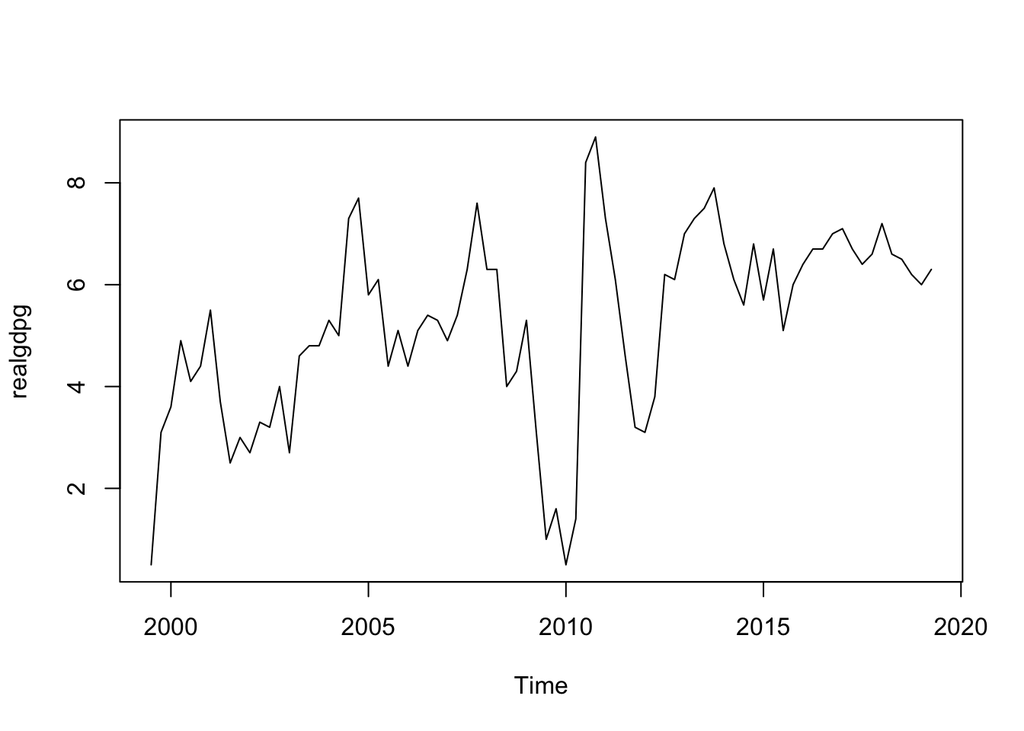

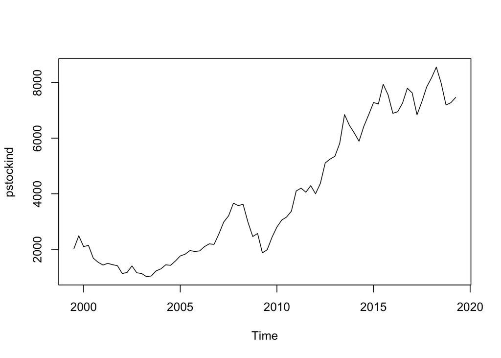

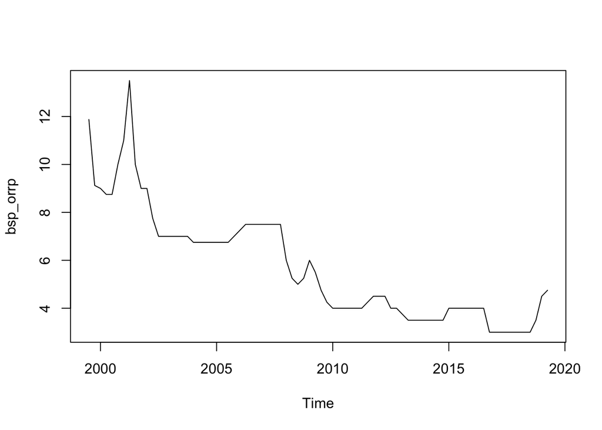

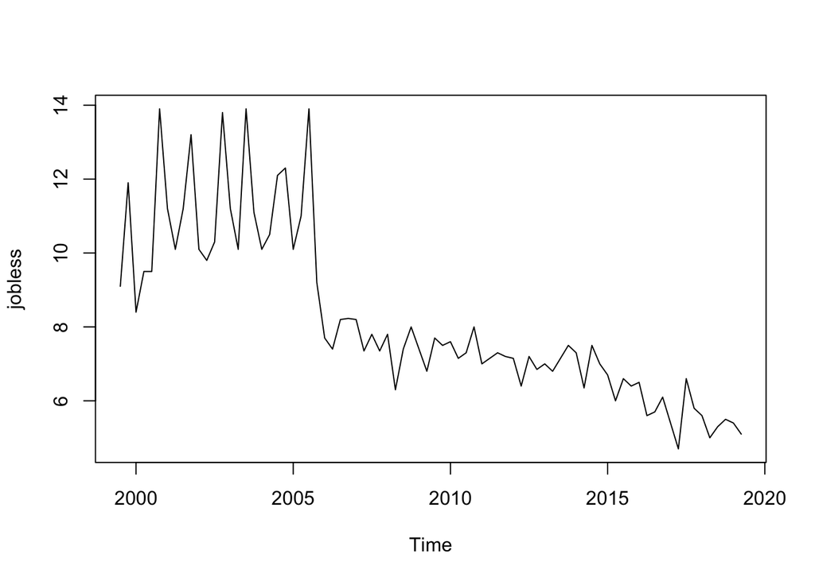

## We should assess whether the variables are stationary. We’ll use the Phillips Perron unit root test to indicate the number of lags in our data.

```r
PP.test(bsp_orrp, lshort = TRUE)
```

```
##
##  Phillips-Perron Unit Root Test
##
## data:  bsp_orrp
## Dickey-Fuller = -3.5056, Truncation lag parameter = 3, p-value = 0.047
```

```r
PP.test(jobless, lshort = TRUE)
```

```
##
##  Phillips-Perron Unit Root Test
##
## data:  jobless
## Dickey-Fuller = -6.3416, Truncation lag parameter = 3, p-value = 0.01
```

```r
PP.test(pstockind, lshort = TRUE)
```

```
##
##  Phillips-Perron Unit Root Test
##
## data:  pstockind
## Dickey-Fuller = -2.5498, Truncation lag parameter = 3, p-value = 0.3507
```

```r
PP.test(realgdpg, lshort = TRUE)
```

```
##
##  Phillips-Perron Unit Root Test
##
## data:  realgdpg
## Dickey-Fuller = -4.5867, Truncation lag parameter = 3, p-value = 0.01
```

### In this estimation above, we find that the variables are stationary, except for the pstockind variable. We still run the VAR estimation using level data, however, we will be more confident in our stationary variable results and predictions.

# We can now estimate our VAR. Let’s bind our VAR variables together, then we’ll select the best lag order behind the VAR we will be using.

## Step 1) Binding our VAR system. cbind() groups our time series.

```r
v1 <- cbind(bsp_orrp, jobless, pstockind, realgdpg)
colnames(v1) <- cbind("Overnight_Reverse_Repurchase_Rate", "Unemployement_Rate", "Phillipines_Stock_Exchange_Index", "Real_GDP_Growth")
```

## Step 2) Determine lag order, using the VARselect() command

```r
lagselect <- VARselect(v1, lag.max = 10, type = "const")
lagselect$selection
```

```
## AIC(n)  HQ(n)  SC(n) FPE(n)
##      4      1      1      4
```

### The command suggests lag order 4 or 1.

## Step 3) Estimate a model using the var() command. p is the number of lags used, since we determined that 1 or 4 lags is best, we’ll set this to 4 and stick to the Akaike Information Criterion output.

```r
UVARModel1 <- VAR(v1, p = 4, type = "const", season = NULL, exog = NULL)
summary(UVARModel1)
```

```
##
## VAR Estimation Results:
## =========================
## Endogenous variables: Overnight_Reverse_Repurchase_Rate, Unemployement_Rate, Phillipines_Stock_Exchange_Index, Real_GDP_Growth
## Deterministic variables: const
## Sample size: 76
## Log Likelihood: -819.816
## Roots of the characteristic polynomial:
## 0.9805 0.9511 0.8293 0.8293 0.7838 0.7739 0.7739 0.6855 0.6855 0.619 0.619 0.5886 0.5813 0.5222 0.5222 0.3842
## Call:
## VAR(y = v1, p = 4, type = "const", exogen = NULL)
##
##
## Estimation results for equation Overnight_Reverse_Repurchase_Rate:
## ==================================================================
## Overnight_Reverse_Repurchase_Rate = Overnight_Reverse_Repurchase_Rate.l1 + Unemployement_Rate.l1 + Phillipines_Stock_Exchange_Index.l1 + Real_GDP_Growth.l1 + Overnight_Reverse_Repurchase_Rate.l2 + Unemployement_Rate.l2 + Phillipines_Stock_Exchange_Index.l2 + Real_GDP_Growth.l2 + Overnight_Reverse…
##
##                                        Estimate Std. Error t value Pr(>|t|)
## Overnight_Reverse_Repurchase_Rate.l1  1.013e+00  1.296e-01   7.812 1.14e-10 ***
## Unemployement_Rate.l1                 9.167e-02  6.499e-02   1.411  0.16361
## Phillipines_Stock_Exchange_Index.l1  -2.999e-04  2.175e-04  -1.379  0.17313
## Real_GDP_Growth.l1                    9.696e-02  6.628e-02   1.463  0.14880
## Overnight_Reverse_Repurchase_Rate.l2 -8.085e-02  1.765e-01  -0.458  0.64848
## Unemployement_Rate.l2                 7.387e-02  6.600e-02   1.119  0.26755
## Phillipines_Stock_Exchange_Index.l2   1.694e-04  3.234e-04   0.524  0.60241
## Real_GDP_Growth.l2                   -1.166e-01  8.006e-02  -1.457  0.15053
## Overnight_Reverse_Repurchase_Rate.l3 -1.189e-01  1.653e-01  -0.720  0.47459
## Unemployement_Rate.l3                -1.752e-01  6.451e-02  -2.716  0.00865 **
## Phillipines_Stock_Exchange_Index.l3   1.053e-04  3.272e-04   0.322  0.74873
## Real_GDP_Growth.l3                    5.871e-02  8.053e-02   0.729  0.46888
## Overnight_Reverse_Repurchase_Rate.l4  7.108e-02  1.119e-01   0.635  0.52785
## Unemployement_Rate.l4                 8.262e-02  6.555e-02   1.260  0.21247
## Phillipines_Stock_Exchange_Index.l4   3.445e-06  2.216e-04   0.016  0.98765
## Real_GDP_Growth.l4                    2.330e-02  6.410e-02   0.363  0.71757
## const                                -2.100e-01  7.910e-01  -0.266  0.79153
## ---
## Signif. codes:  0 '***' 0.001 '**' 0.01 '*' 0.05 '.' 0.1 ' ' 1
##
##
## Residual standard error: 0.6205 on 59 degrees of freedom
```

[output cut: 126 more lines]

```
##                                   Unemployement_Rate
## Overnight_Reverse_Repurchase_Rate           0.027238
## Unemployement_Rate                          1.000000
## Phillipines_Stock_Exchange_Index           -0.030321
## Real_GDP_Growth                             0.009137
##                                   Phillipines_Stock_Exchange_Index
## Overnight_Reverse_Repurchase_Rate                         -0.05980
## Unemployement_Rate                                        -0.03032
## Phillipines_Stock_Exchange_Index                           1.00000
## Real_GDP_Growth                                            0.12506
##                                   Real_GDP_Growth
## Overnight_Reverse_Repurchase_Rate        0.094141
## Unemployement_Rate                       0.009137
## Phillipines_Stock_Exchange_Index         0.125065
## Real_GDP_Growth                          1.000000
```

# Model Diagnosis

## An assumption of VAR is that the residuals should be non-auto-correlated. Building upon the assumption that the residuals are not correlated with prior periods.

```r
Serial1 <- serial.test(UVARModel1, lags.pt = 15, lags.bg = 5, type = "PT.asymptotic")
Serial1
```

```
##
##  Portmanteau Test (asymptotic)
##
## data:  Residuals of VAR object UVARModel1
## Chi-squared = 151.77, df = 176, p-value = 0.9066
```

## We want to examine the VAR to see if there is heteroscedasticity, which would result in a change in the variance in the residuals

```r
Arch1 <- arch.test(UVARModel1, lags.multi = 4
, multivariate.only = TRUE)
Arch1
```

```
##
##  ARCH (multivariate)
##
## data:  Residuals of VAR object UVARModel1
## Chi-squared = 422, df = 400, p-value = 0.2155
```

### Fail to reject null hypothesis, there is no heteroscedasticity in the model

## Now we want to test the normality of the residuals distribution.

```r
Norm1 <- normality.test(UVARModel1, multivariate.only = TRUE)
Norm1
```

```
## $JB
##
##  JB-Test (multivariate)
##
## data:  Residuals of VAR object UVARModel1
## Chi-squared = 129.45, df = 8, p-value < 2.2e-16
##
##
## $Skewness
##
##  Skewness only (multivariate)
##
## data:  Residuals of VAR object UVARModel1
## Chi-squared = 6.4981, df = 4, p-value = 0.1649
##
##
## $Kurtosis
##
##  Kurtosis only (multivariate)
##
## data:  Residuals of VAR object UVARModel1
## Chi-squared = 122.95, df = 4, p-value < 2.2e-16
```

## JB-test and Kurtosis show significant difference from the normal distribution, but skewness appears to be normally distributed. We should assume that the residuals are not normally distributed in this case.

## Now we want to test for structural breaks using the stability test. If there is a structural breaks, the whole estimation would be inaccurate.

```r
Stability1 <- stability(UVARModel1, type = "OLS-CUSUM")
par("mar")
```

```
## [1] 5.1 4.1 4.1 2.1
```

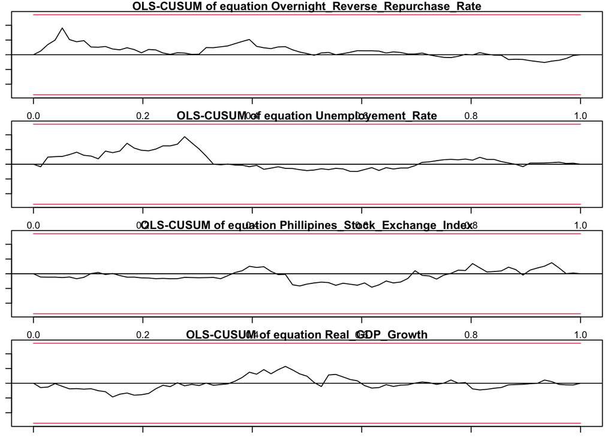

```r
par(mar=c(1,1,1,1))
plot(Stability1)
```

### Based on these results, there is no structural breaks as the red lines are untouched

# Policy Simulations

```r
GrangerJobless <- causality(UVARModel1, cause = "Unemployement_Rate")
GrangerJobless
```

```
## $Granger
##
##  Granger causality H0: Unemployement_Rate do not Granger-cause
##  Overnight_Reverse_Repurchase_Rate Phillipines_Stock_Exchange_Index
##  Real_GDP_Growth
##
## data:  VAR object UVARModel1
## F-Test = 1.427, df1 = 12, df2 = 236, p-value = 0.1543
##
##
## $Instant
##
##  H0: No instantaneous causality between: Unemployement_Rate and
##  Overnight_Reverse_Repurchase_Rate Phillipines_Stock_Exchange_Index
##  Real_GDP_Growth
##
## data:  VAR object UVARModel1
## Chi-squared = 0.1273, df = 3, p-value = 0.9884
```

```r
GrangerStock <- causality(UVARModel1, cause = "Phillipines_Stock_Exchange_Index")
GrangerStock
```

```
## $Granger
##
##  Granger causality H0: Phillipines_Stock_Exchange_Index do not
##  Granger-cause Overnight_Reverse_Repurchase_Rate Unemployement_Rate
##  Real_GDP_Growth
##
## data:  VAR object UVARModel1
## F-Test = 1.5517, df1 = 12, df2 = 236, p-value = 0.1069
##
##
## $Instant
##
##  H0: No instantaneous causality between:
##  Phillipines_Stock_Exchange_Index and Overnight_Reverse_Repurchase_Rate
##  Unemployement_Rate Real_GDP_Growth
##
## data:  VAR object UVARModel1
## Chi-squared = 1.6131, df = 3, p-value = 0.6564
```

```r
GrangerGDPG <- causality(UVARModel1, cause = "Real_GDP_Growth")
GrangerGDPG
```

```
## $Granger
##
##  Granger causality H0: Real_GDP_Growth do not Granger-cause
##  Overnight_Reverse_Repurchase_Rate Unemployement_Rate
##  Phillipines_Stock_Exchange_Index
##
## data:  VAR object UVARModel1
## F-Test = 0.96938, df1 = 12, df2 = 236, p-value = 0.4789
##
##
## $Instant
##
##  H0: No instantaneous causality between: Real_GDP_Growth and
##  Overnight_Reverse_Repurchase_Rate Unemployement_Rate
##  Phillipines_Stock_Exchange_Index
##
## data:  VAR object UVARModel1
## Chi-squared = 1.934, df = 3, p-value = 0.5862
```

```r
GrangerORRP<- causality(UVARModel1, cause = "Overnight_Reverse_Repurchase_Rate")
GrangerORRP
```

```
## $Granger
##
##  Granger causality H0: Overnight_Reverse_Repurchase_Rate do not
##  Granger-cause Unemployement_Rate Phillipines_Stock_Exchange_Index
##  Real_GDP_Growth
##
## data:  VAR object UVARModel1
## F-Test = 0.79041, df1 = 12, df2 = 236, p-value = 0.6602
##
##
## $Instant
##
##  H0: No instantaneous causality between:
##  Overnight_Reverse_Repurchase_Rate and Unemployement_Rate
##  Phillipines_Stock_Exchange_Index Real_GDP_Growth
##
## data:  VAR object UVARModel1
## Chi-squared = 1.0972, df = 3, p-value = 0.7778
```

## Impulse Response Functions

We will now turn to our impulse response functions. While we can get more impulse response functions than the ones below, we will zero in on the impact of a shock in ORRP to the other variables in the system.

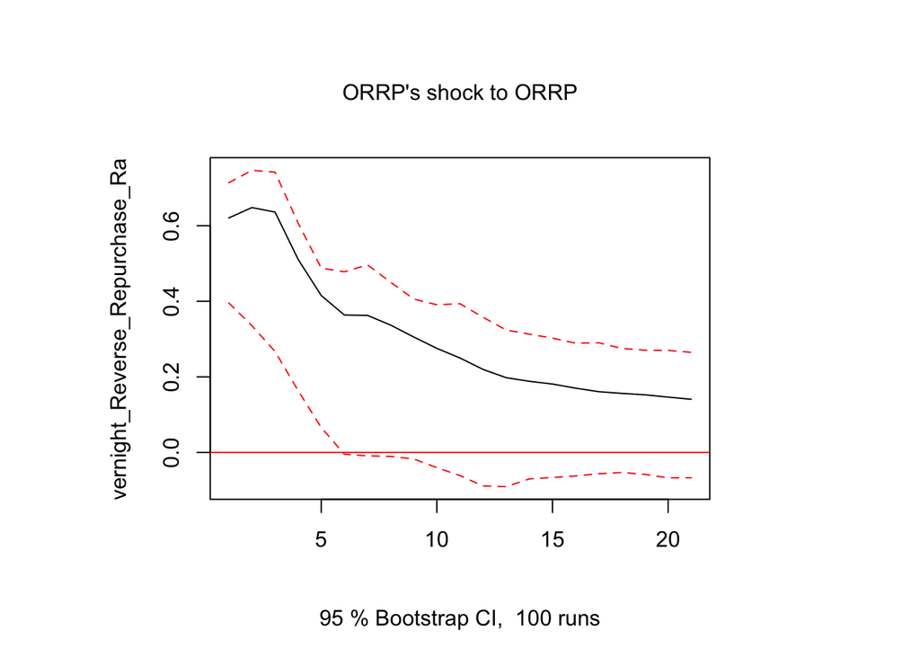

```r
ORRPirf <- irf(UVARModel1, impulse = "Overnight_Reverse_Repurchase_Rate", response = "Overnight_Reverse_Repurchase_Rate", n.ahead = 20, boot = TRUE)
plot(ORRPirf, ylab = "Overnight_Reverse_Repurchase_Rate", main = "ORRP's shock to ORRP")
```

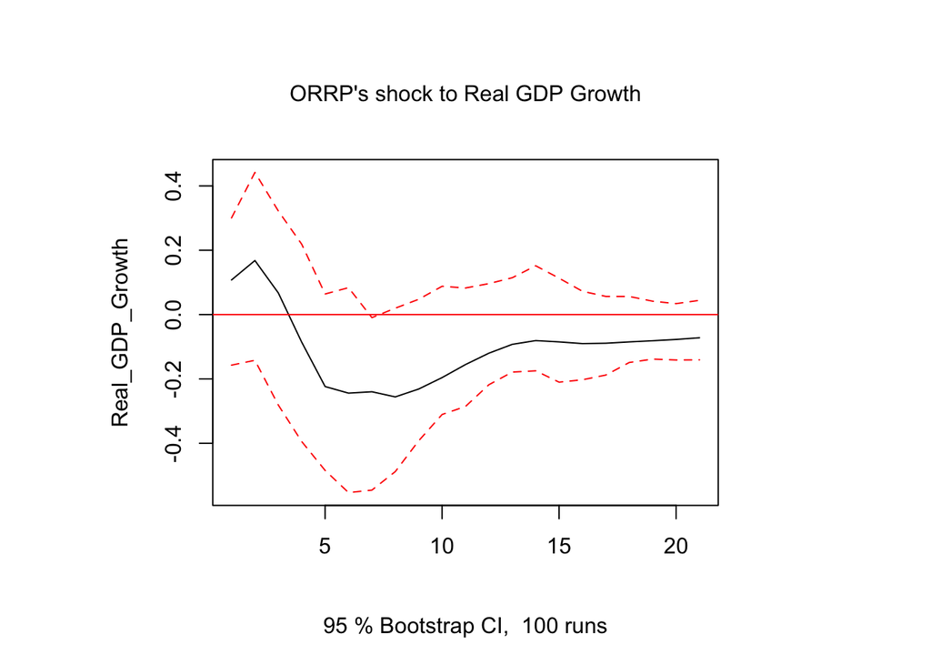

```r
RGDPGirf <- irf(UVARModel1, impulse = "Overnight_Reverse_Repurchase_Rate", response = "Real_GDP_Growth", n.ahead = 20, boot = TRUE)

plot(RGDPGirf, ylab = "Real_GDP_Growth", main = "ORRP's shock to Real GDP Growth")
```

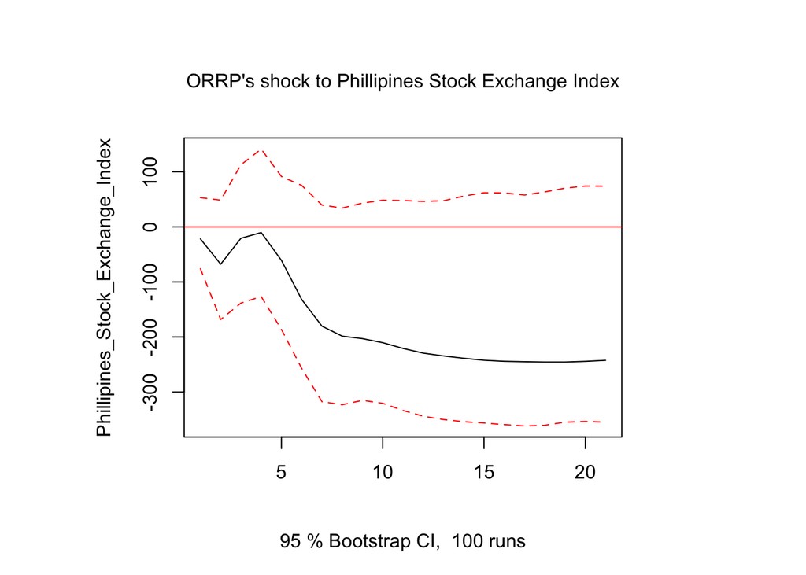

```r
PSEIirf <- irf(UVARModel1, impulse = "Overnight_Reverse_Repurchase_Rate", response = "Phillipines_Stock_Exchange_Index", n.ahead = 20, boot = TRUE)

plot(PSEIirf, ylab = "Phillipines_Stock_Exchange_Index", main = "ORRP's shock to Phillipines Stock Exchange Index")
```

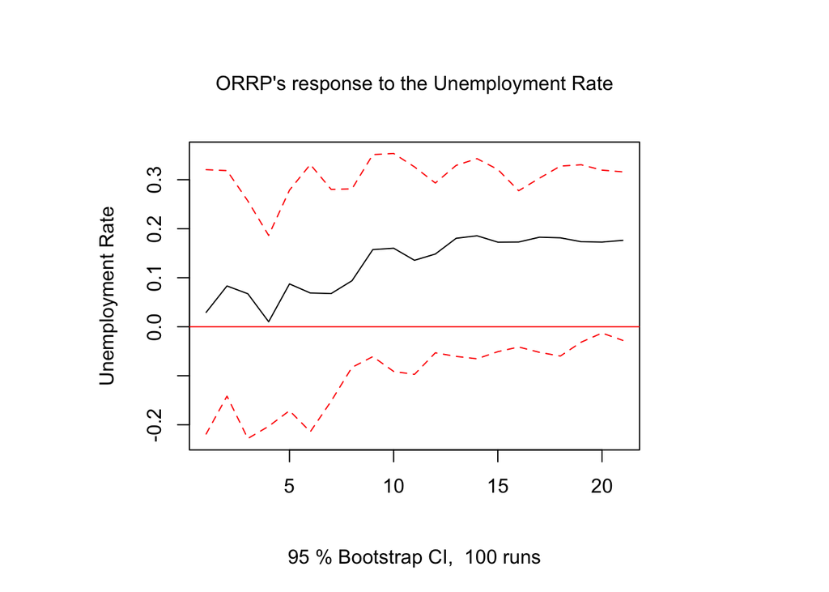

```r
Joblessirf <- irf(UVARModel1, impulse = "Overnight_Reverse_Repurchase_Rate", response = "Unemployement_Rate", n.ahead = 20, boot = TRUE)
plot(Joblessirf, ylab = "Unemployment Rate", main = "ORRP's response to the Unemployment Rate")
```

# Forecasting using VAR

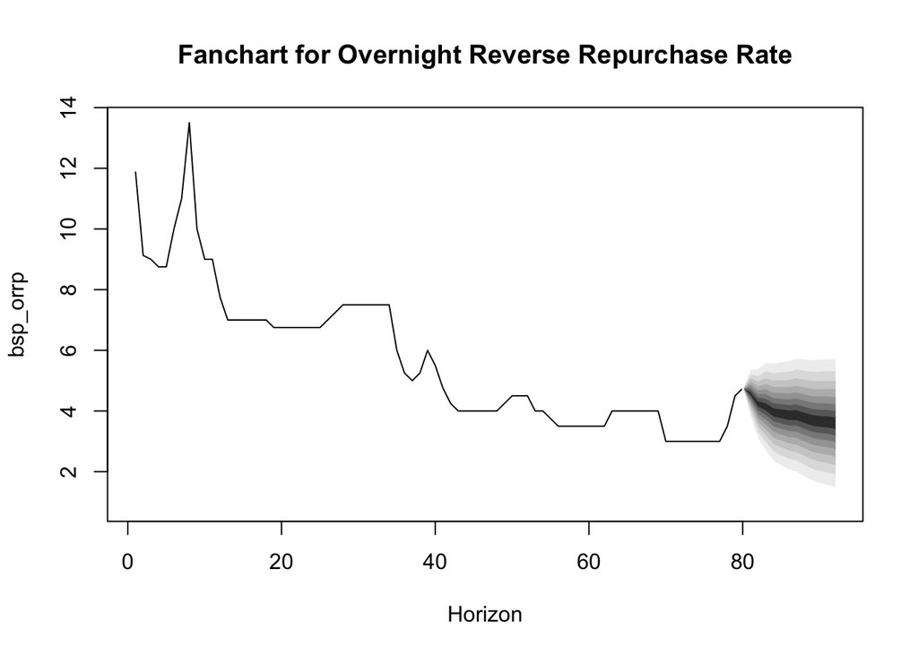

```r
forecast <- predict(UVARModel1, n.ahead = 12, ci = 0.95)

fanchart(forecast, names = "bsp_orrp", main = "Fanchart for Overnight Reverse Repurchase Rate", xlab = "Horizon", ylab = "bsp_orrp")
```

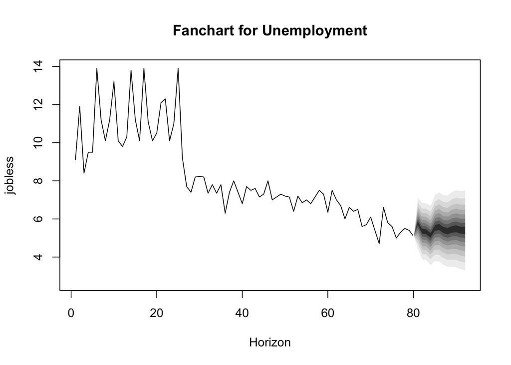

```r
fanchart(forecast, names = "Unemployement_Rate", main = "Fanchart for Unemployment", xlab = "Horizon", ylab = "jobless")
```

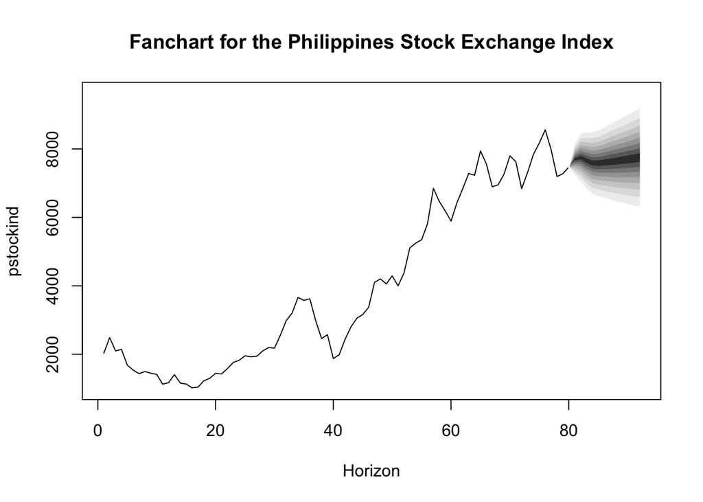

```r
fanchart(forecast, names = "Phillipines_Stock_Exchange_Index", main = "Fanchart for the Philippines Stock Exchange Index", xlab = "Horizon", ylab = "pstockind")
```

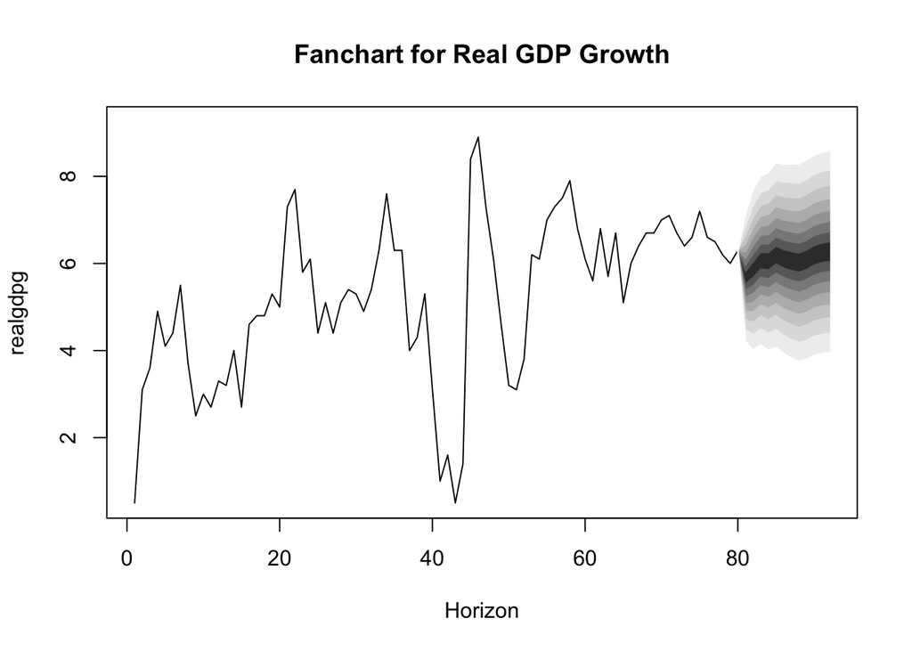

```r
fanchart(forecast, names = "Real_GDP_Growth", main = "Fanchart for Real GDP Growth", xlab = "Horizon", ylab = "realgdpg")
```